# lab-07

Author

Andre Gala-Garza

Published

February 26, 2026

**Disclaimer:** Generative AI was used to assist with templating and writing code in this assignment; however, this code was checked manually and edited by hand to ensure accuracy.

**Source:** OpenAI. (2026). *ChatGPT (GPT-5.2 Thinking)* [Large language model]. https://chatgpt.com/.

# 1. How many Sars-Cov-2 papers?

```r
# Downloading the website
website <- xml2::read_html("https://pubmed.ncbi.nlm.nih.gov/?term=sars-cov-2")

# Finding the counts
counts <- xml2::xml_find_first(website, "//div[@class='results-amount']//span[@class='value']/text()")

# Turning it into text
counts <- as.character(counts)

# Extracting the data using regex
totalcount <- stringr::str_extract(counts, "[0-9][0-9,\\.]*")

# Removing any commas/dots so that we can convert to numeric
totalcount <- gsub("[,\\.]", "", totalcount)

totalcount <- as.numeric(totalcount)
print(totalcount)
```

```
[1] 270119
```

# 2. Get article abstracts and authors

```r
# read in text, each line is a separate character
abstracts <- readLines('abstract-sars-cov-2-set.txt', warn = FALSE)

# combine all text into one character
abstracts <- paste(abstracts, collapse = "\n")

# split the text whenever 3 new lines occur in a row (indicating two blank lines)
abstracts <- strsplit(abstracts, "\n{3,}")

# replace any remaining "\n" symbols with spaces
abstracts <- gsub("\n", " ", abstracts)

# replace multiple spaces with single space
abstracts <- gsub("\\s+", " ", abstracts)
```

# 3. Distribution of universities

```r
library(stringr)

institution <- str_extract_all(
  abstracts,
  "\\b(?:The\\s+)?(?:University of\\s+[A-Za-z][A-Za-z\\-]*(?:\\s+[A-Za-z][A-Za-z\\-]*)*|[A-Z][A-Za-z\\-]*(?:\\s+[A-Z][A-Za-z\\-]*)*\\s+(?:State\\s+)?University|[A-Z][A-Za-z\\-]*(?:\\s+[A-Z][A-Za-z\\-]*)*\\s+Institute of\\s+[A-Za-z][A-Za-z\\-]*(?:\\s+[A-Za-z][A-Za-z\\-]*)*)\\b"
)

institution <- unlist(institution)
```

```r
head(table(institution))
```

```
institution
           A T Still University                Aalto University
                              1                               1
              Aarhus University            Abdulaziz University
                              3                               1
              Acadia University Acharya Institute of Technology
                              1                               1
```

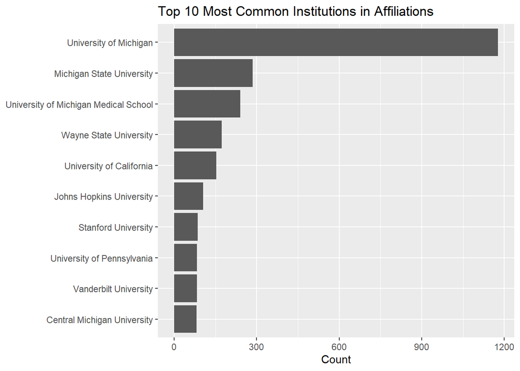

```r
library(dplyr)
library(ggplot2)

tab <- sort(table(institution), decreasing = TRUE)

top10 <- data.frame(
  institution = names(tab)[1:10],
  n = as.integer(tab[1:10]),
  stringsAsFactors = FALSE
) |>
  mutate(institution = factor(institution, levels = rev(institution)))

ggplot(top10, aes(x = n, y = institution)) +
  geom_col() +
  labs(
    title = "Top 10 Most Common Institutions in Affiliations",
    x = "Count",
    y = NULL
  )
```

From this bar chart, we see that the University of Michigan is the most common university mentioned in the PubMed abstracts in the state of Michigan from 2020 to 2021, which makes perfect sense. This is followed by Michigan State University, the UMich Medical School, and Wayne State University, which also make sense.

Some ways that these results could be improved are to normalize the names before counting so that e.g. “UMich” becomes “University of Michigan”, make the regex more specific to university names such as “Institute of…” or “College of…”, and deduplication within one abstract so that if a university name appears multiple times in one abstract, it isn’t counted more than once.

# 4. Make a tidy dataset

```r
# read in text, each line is a separate character
abstracts <- readLines('abstract-sars-cov-2-set.txt', warn = FALSE)

# combine all text into one character
abstracts <- paste(abstracts, collapse = "\n")

# split the text whenever 3 new lines occur in a row (indicating two blank lines)
abstracts <- strsplit(abstracts, "\n{3,}")[[1]]
```

```r
library(stringr)

journal <- str_match(abstracts, "(?m)^\\s*\\d+\\.\\s*(.*?)\\s+\\d{4}\\b")[,2]
```

```r
titles <- sapply(abstracts, function(x){
  parts <- unlist(strsplit(x, split = "\n\n"))
  parts <- parts[parts != ""]          # drop empty chunks from extra blank lines
  parts[2]
}, USE.NAMES = FALSE)
```

```r
library(stringr)

authors <- sapply(abstracts, function(x){
  parts <- unlist(strsplit(x, split = "\n\n"))
  parts <- parts[parts != ""]
  a <- parts[3]              # authors are the 3rd non-empty block
  gsub("\n", " ", a)         # remove any single newline within long author lists
}, USE.NAMES = FALSE)

authors <- gsub("\\s+", " ", authors)
```

```r
affiliations <- str_extract(
  abstracts,
  "(?s)\\n\\nAuthor information:\\n\\n.*?\\n\\n"
)
```

```r
papers <- data.frame(
  journal = journal,
  title = titles,
  authors = stringr::str_trunc(authors, width = 100, side = "right", ellipsis = "..."),
  affiliations = stringr::str_trunc(affiliations, width = 100, side = "right", ellipsis = "..."),
  stringsAsFactors = FALSE
)

knitr::kable(papers[1:5, ])
```

| journal | title | authors | affiliations |
| --- | --- | --- | --- |
| Viruses. | Viewpoint: Origin of SARS-CoV-2. | Lundstrom K(1), Seyran M(2)(3), Pizzol D(4), Adadi P(5), Mohamed Abd El-Aziz T(6)(7), Hassan SS(8… | NA |
| J Mol Biol. | Mutations Strengthened SARS-CoV-2 Infectivity. | Chen J(1), Wang R(1), Wang M(1), Wei GW(2). | NA |
| J Med Chem. | Perspectives on SARS-CoV-2 Main Protease Inhibitors. | Gao K(1), Wang R(1), Chen J(1), Tepe JJ(2), Huang F(3), Wei GW(1)(4)(5). | NA |
| JCI Insight. | SARS-CoV-2 vaccines: a triumph of science and collaboration. | Golob JL(1), Lugogo N(2), Lauring AS(1), Lok AS(3). | NA |
| J Clin Virol. | SARS-CoV-2: Is it the newest spark in the TORCH? | Muldoon KM(1), Fowler KB(2), Pesch MH(3), Schleiss MR(4). | NA |